# Data Analytics UE17CS322

### Assignment-1

#### Name: Gagana G. S.

#### SRN: PES1201700952

```r
#Packages being used
```

```r
c=getwd()
#path
path=setwd(c)
```

```r
#Reading the datasets
employee_survey_data <- read.csv("employee_survey_data.csv")
general_data<-read.csv("general_data.csv")
manager_survey_data<-read.csv("manager_survey_data.csv")
```

```r
#Preparing the dataset
#Removing all tuples having na values
employee_survey_data_na<-na.omit(employee_survey_data)
general_data_na<-na.omit(general_data)
manager_survey_data_na<-na.omit(manager_survey_data)

#Performing natural join on the 3 datasets
fdataset <- merge(employee_survey_data_na,general_data_na,by="EmployeeID")
#final dataset is fds
fds<-merge(fdataset,manager_survey_data_na,by="EmployeeID")
```

## Question-1

#### 1 a.

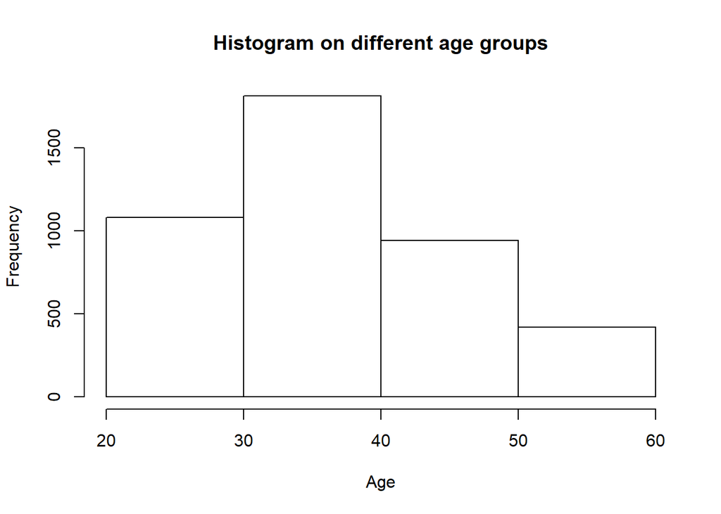

```r
#Finding the upper limit of age attribute and applying ceil operation(as interval needs to be in 10's)
m<-max(fds$Age)
#print(m)
if(m%%10!=0){
  m1<-((m/10 +1) * 10)
}else{
  m1<-m
}
#Creating the subset of the dataset as age>=20
d<-fds[!(fds$Age<20),]
hist(d$Age,
     main="Histogram on different age groups",
     xlab="Age",
     ylab="Frequency",
     breaks=c(seq(20,m1,10)))
```

#### Nature of the graph is not symmetric

#### Its skewed towards right or positively skewed

```r
#To pick the interval with maximum average income
t=mean(d$MonthlyIncome[d$Age>=20 & d$Age<30])
l=20
u=30
i=1
j=1
m1<-t
while(i<=3){
    t=mean(d$MonthlyIncome[d$Age>=(l+i*10) &   d$Age<(u+i*10)])
if(t>m1){
  m1=t
  j=i
}
i=i+1

}
#Prints the maximum average monthly income
print(m1)
```

```
## [1] 65937.94
```

```r
#Calucates and prints the lower limit of the age interval whose average monthly salary is maximum
l1=l+j*10
l2=u*10
print(l1)
```

```
## [1] 40
```

```r
#Therefore the interval is 40-50
```

#### The interval with maximum average Monthly Income belongs to the age group 40-50

#### 1 b.

```r
#Extracting the tuples whose age belongs to interval 40-49
b1=d[d$Age>=40 & d$Age<50,]

# Ordering in descending order based on Monthly Income
b2=b1[order(-b1$MonthlyIncome),]

#Extracting only 3 columns
b3 = data.frame(employeeID=b2$EmployeeID, MonthlyIncome=b2$MonthlyIncome, TotalWorkingYears=b2$TotalWorkingYears)
#Extracting unique salaries
salary=unique(b3$MonthlyIncome)
#print(salary[6])
#Printing rows with 5 highest Monthly Income
b4=b3[which(b3$MonthlyIncome>salary[6]),]
print(b4)
```

```
##    employeeID MonthlyIncome TotalWorkingYears
## 1         386        199990                17
## 2        1856        199990                17
## 3        3326        199990                17
## 4        1047        199430                15
## 5        2517        199430                15
## 6        3987        199430                15
## 7        1094        197400                24
## 8        2564        197400                24
## 9        4034        197400                24
## 10       1152        197170                10
## 11       2622        197170                10
## 12       4092        197170                10
## 13        966        196270                25
## 14       2436        196270                25
## 15       3906        196270                25
```

#### 1 c.

```r
#Extracting unique job roles
jrole=unique(b1$JobRole)
print(jrole)
```

```
## [1] Research Director         Laboratory Technician
## [3] Research Scientist        Sales Executive
## [5] Manufacturing Director    Healthcare Representative
## [7] Manager                   Sales Representative
## [9] Human Resources
## 9 Levels: Healthcare Representative ... Sales Representative
```

```r
i=1
s1=c()
#Valculates average income on each job roles
while(i<=9){
  s1[i]=mean(b1$MonthlyIncome[b1$JobRole==jrole[i]])
  i=i+1

}
print(s1)
```

```
## [1] 50428.69 67212.12 68158.59 62928.06 66236.48 56252.05 78585.26 81536.83
## [9] 80234.44
```

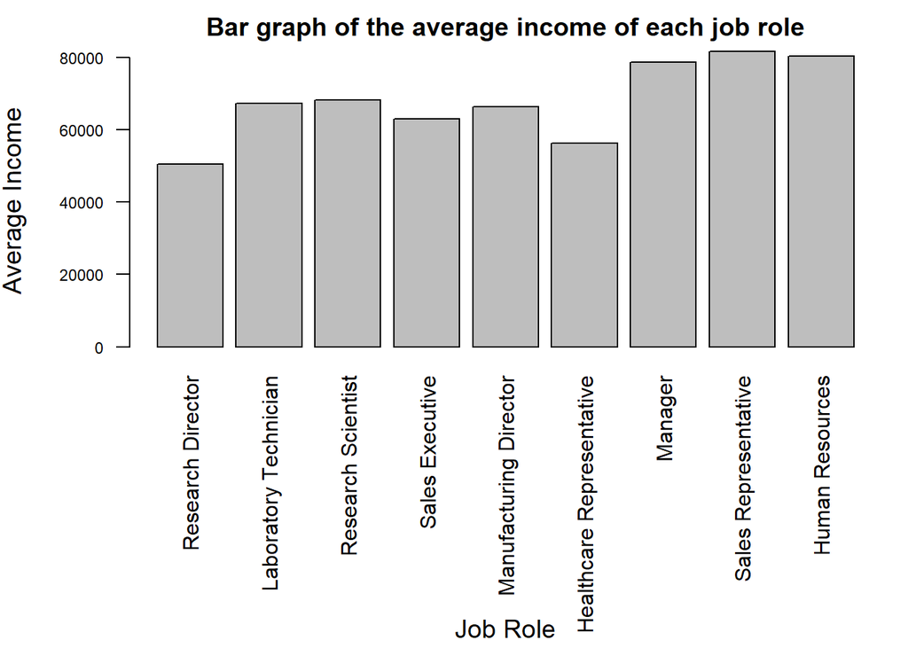

```r
#margin=par(mar=c(11,5,4,1))
par(mar = c(11.5,5,2,1), mgp = c(4, 1, 0))
barplot(s1,main="Bar graph of the average income of each job role",ylab="Average Income",xlab="",las=2,names.arg=jrole,cex.lab=1.2,cex.axis=0.75)
title(xlab="Job Role", cex.lab=1.2,cex.axis=0.75,mgp=c(10.3,1,0))
```

## Question-2

```r
f1<-fds[fds$Gender=="Female",]
# Stacked Bar Plot with Colors and Legend
count1 <- table(f1$MaritalStatus, f1$EnvironmentSatisfaction)
print(count1)
```

```
##
##              1   2   3   4
##   Divorced  56  82  98 124
##   Married  123 194 285 220
##   Single   115  98 142 192
```

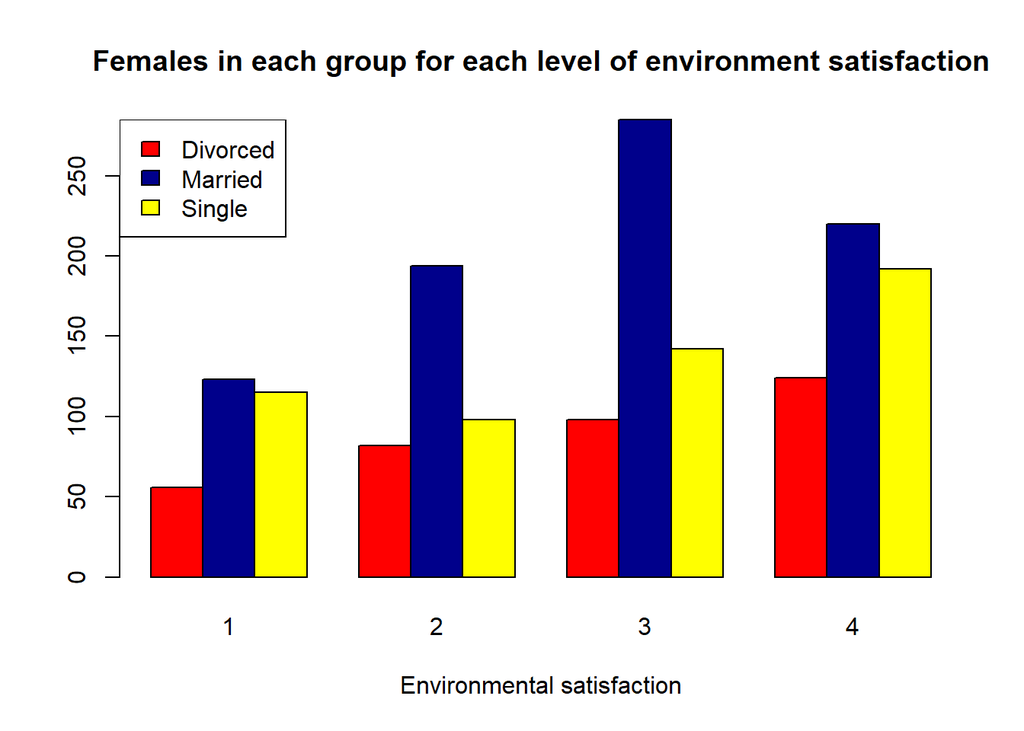

```r
barplot(count1, main="Females in each group for each level of environment satisfaction",  xlab="Environmental satisfaction", col=c("red","darkblue","yellow"),
  beside=TRUE)
legend(legend = rownames(count1),fill = c("red","darkblue","yellow"),"topleft")
```

## Question-3

```r
count2=table(fds$Department,fds$Attrition)

print(count2)
```

```
##
##                            No  Yes
##   Human Resources         132   54
##   Research & Development 2364  443
##   Sales                  1109  198
```

```r
p1=count2[1,2]/(count2[1,1]+count2[1,2])
p2=count2[2,2]/(count2[3,1]+count2[3,2])
p3=count2[3,2]/(count2[3,1]+count2[3,2])
res=min(p1,p2,p3)
#Required percentage is res
#print("The department with least attrition in terms of percentage of employees in that department")
if(res==p1){
  print("Human Resources")
}else if(res==p2){
  print("Research & Development")
}else{
  print("Sales")
}
```

```
## [1] "Sales"
```

#### The department with least attrition in terms of percentage of employees in that department is Sales

## Question-4

#### 4 a.

```r
input= fds[,c('MonthlyIncome','EducationField')]
print(head(input))
```

```
##   MonthlyIncome EducationField
## 1        131160  Life Sciences
## 2         41890  Life Sciences
## 3        193280          Other
## 4         83210  Life Sciences
## 5         23420        Medical
## 6         40710  Life Sciences
```

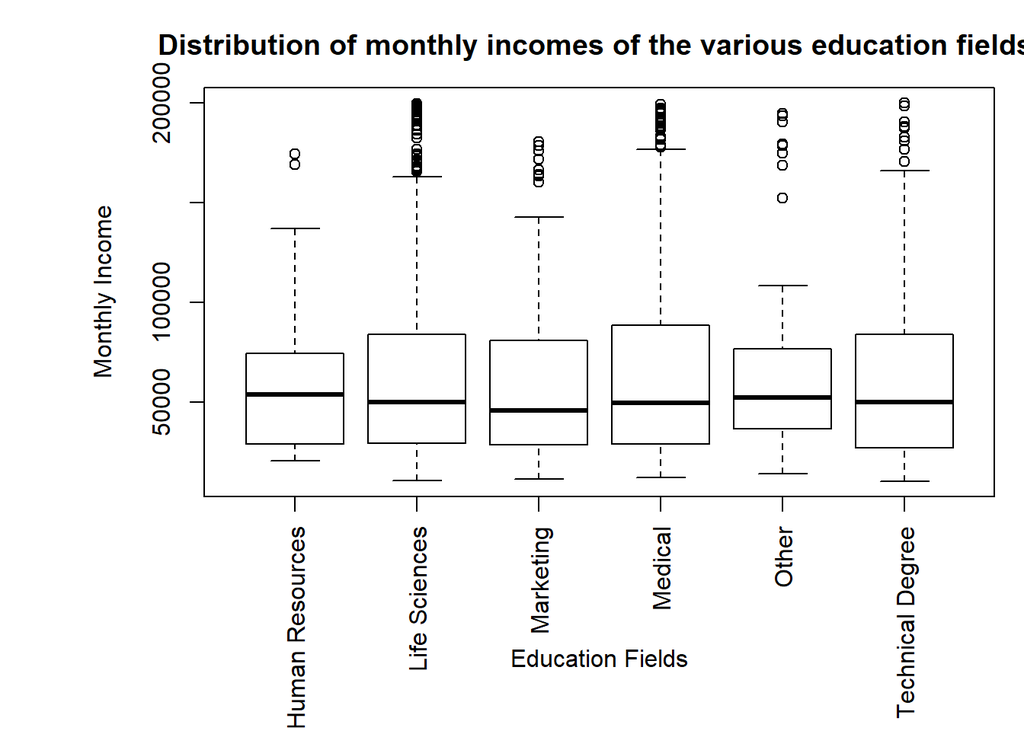

```r
par(mar = c(8,7,3,1))
bp=boxplot(MonthlyIncome ~ EducationField, data = fds, xlab = "",
   ylab = "Monthly Income", main = "Distribution of monthly incomes of the various education fields.",las=3)
title(xlab="Education Fields", mgp = c(5, 1, 0))
```

```r
#Summary statistics
tapply(fds$MonthlyIncome,fds$EducationField,summary)
```

```
## $`Human Resources`
##    Min. 1st Qu.  Median    Mean 3rd Qu.    Max.
##   20610   28750   53730   60523   74460  174260
##
## $`Life Sciences`
##    Min. 1st Qu.  Median    Mean 3rd Qu.    Max.
##   10510   29420   49735   65393   83800  199430
##
## $Marketing
##    Min. 1st Qu.  Median    Mean 3rd Qu.    Max.
##   11290   28370   45680   59303   80950  180410
##
## $Medical
##    Min. 1st Qu.  Median    Mean 3rd Qu.    Max.
##   12320   29110   49655   66973   88340  199260
##
## $Other
##    Min. 1st Qu.  Median    Mean 3rd Qu.    Max.
##   13930   36690   52100   66666   76550  194360
##
## $`Technical Degree`
##    Min. 1st Qu.  Median    Mean 3rd Qu.    Max.
##   10090   27030   49990   63718   83810  199990
```

#### 4 b.

```r
f7<-fds[fds$Gender=="Female",]
f8<-fds[fds$Gender=="Male",]
print("Average salary of feamle and male respectively")
```

```
## [1] "Average salary of feamle and male respectively"
```

```r
mean(f7$MonthlyIncome)
```

```
## [1] 64707.36
```

```r
mean(f8$MonthlyIncome)
```

```
## [1] 65296.89
```

```r
print("Maximum salary of female and male respectively")
```

```
## [1] "Maximum salary of female and male respectively"
```

```r
max(f7$MonthlyIncome)
```

```
## [1] 199990
```

```r
max(f8$MonthlyIncome)
```

```
## [1] 199730
```

#### On calculating the average salary, maximum salary for female and male we dont find much difference in the wage

#### 4 c.

#### 95th percentile monthly income for the Medical Education Field.

```r
f5<-fds[fds$EducationField=="Medical",]
temp = f5$MonthlyIncome
quantile(temp, c(.95) )
```

```
##    95%
## 183000
```

## Question-5

#### Skewness talks about the symmetry in the distribution. Positive skewness is when the right tail of the distribution is flat.In this case mean and median are greater than the mode.Negative skewness is when the left tail of the distribution is flat.In this case mean and median are lesser than the mode. Kurtosis is the measure of peakedness.Kurtosis measures extreme values in either tail. Distributions with large kurtosis exhibit tail data exceeding the tails of the normal distribution (e.g., five or more standard deviations from the mean). Distributions with low kurtosis exhibit tail data that are generally less extreme than the tails of the normal distribution.